# EP10-respuesta-equipo-8

2025-06-09

## Contexto

Para este ejercicio usaremos los datos de medidas anatómicas recolectados por Heinz et al. (2003) que ya conocimos en el ejercicio práctico anterior (disponibles en el archivo “EP09 Datos.csv”). Como en este case se requiere de una variable dicotómica, vamos a realizar lo siguiente:

1. El equipo crea la variable IMC (índice de masa corporal) como el peso de una persona (en kilogramos) dividida por el cuadrado de su estatura (en metros).
2. Si bien esta variable se usa para clasificar a las personas en varias clases de estado nutricional (bajo peso, normal, sobrepeso, obesidad, obesidad mórbida), para efectos de este ejercicio, usaremos dos clases: sobrepeso (IMC ≥ 23,2) y no sobrepeso (IMC < 23,2).
3. El equipo crea la variable dicotómica EN (estado nutricional) de acuerdo al valor de IMC de cada persona.

## Actividad

En primer lugar se cargan los datos del archivo `EP09 Datos.csv` y se visualizan las primeras filas para entender la estructura de los datos.

```r
#Cargar archivo de datos
datos <- read.csv2("EP09 Datos.csv")

#Visualizar datos
head(datos)
```

```
##   Biacromial.diameter Biiliac.diameter Bitrochanteric.diameter Chest.depth
## 1                42.9             26.0                    31.5        17.7
## 2                43.7             28.5                    33.5        16.9
## 3                40.1             28.2                    33.3        20.9
## 4                44.3             29.9                    34.0        18.4
## 5                42.5             29.9                    34.0        21.5
## 6                43.3             27.0                    31.5        19.6
##   Chest.diameter Elbows.diameter Wrists.diameter Knees.diameter Ankles.diameter
## 1           28.0            13.1            10.4           18.8            14.1
## 2           30.8            14.0            11.8           20.6            15.1
## 3           31.7            13.9            10.9           19.7            14.1
## 4           28.2            13.9            11.2           20.9            15.0
## 5           29.4            15.2            11.6           20.7            14.9
## 6           31.3            14.0            11.5           18.8            13.9
##   Shoulder.Girth Chest.Girth Waist.Girth Navel.Girth Hip.Girth Thigh.Girth
```

[output cut: 20 more lines]

Luego, se crea la variable IMC correspondiente al índice de masa corporal, este se calcula a través de la división del peso de una persona (Weight) con la altura al cuadrado (Height), teniendo en cuenta que las unidades de medida están en kilogramos para el peso y en metros para la altura.

```r
# Crear variable IMC
datos$IMC <- datos$Weight / ((datos$Height*0.01)^2)

# Visualizar las primeras filas para verificar la creación de la variable
head(datos)
```

```
##   Biacromial.diameter Biiliac.diameter Bitrochanteric.diameter Chest.depth
## 1                42.9             26.0                    31.5        17.7
## 2                43.7             28.5                    33.5        16.9
## 3                40.1             28.2                    33.3        20.9
## 4                44.3             29.9                    34.0        18.4
## 5                42.5             29.9                    34.0        21.5
## 6                43.3             27.0                    31.5        19.6
##   Chest.diameter Elbows.diameter Wrists.diameter Knees.diameter Ankles.diameter
## 1           28.0            13.1            10.4           18.8            14.1
## 2           30.8            14.0            11.8           20.6            15.1
## 3           31.7            13.9            10.9           19.7            14.1
## 4           28.2            13.9            11.2           20.9            15.0
## 5           29.4            15.2            11.6           20.7            14.9
## 6           31.3            14.0            11.5           18.8            13.9
##   Shoulder.Girth Chest.Girth Waist.Girth Navel.Girth Hip.Girth Thigh.Girth
```

[output cut: 20 more lines]

Una vez creada la variable IMC, se procede a crear una variable dicotómica EN. Esta corresponde a una variable dicotómica que indica 2 clases, si el IMC es mayor o igual a 23,2 corresponde a “Sobrepeso” la cual será representada por 1, pero si es menor a 23,2 corresponde a “No sobrepeso”, la cual será representada por 0.

```r
# Crear variable dicotómica EN
datos$EN <- factor(ifelse(datos$IMC >= 23.2, 1, 0),
                   levels = c(0, 1),
                   labels = c("No_sobrepeso", "Sobrepeso"))
# Visualizar las primeras filas para verificar la creación de la variable
head(datos)
```

```
##   Biacromial.diameter Biiliac.diameter Bitrochanteric.diameter Chest.depth
## 1                42.9             26.0                    31.5        17.7
## 2                43.7             28.5                    33.5        16.9
## 3                40.1             28.2                    33.3        20.9
## 4                44.3             29.9                    34.0        18.4
## 5                42.5             29.9                    34.0        21.5
## 6                43.3             27.0                    31.5        19.6
##   Chest.diameter Elbows.diameter Wrists.diameter Knees.diameter Ankles.diameter
## 1           28.0            13.1            10.4           18.8            14.1
## 2           30.8            14.0            11.8           20.6            15.1
## 3           31.7            13.9            10.9           19.7            14.1
## 4           28.2            13.9            11.2           20.9            15.0
## 5           29.4            15.2            11.6           20.7            14.9
## 6           31.3            14.0            11.5           18.8            13.9
##   Shoulder.Girth Chest.Girth Waist.Girth Navel.Girth Hip.Girth Thigh.Girth
```

[output cut: 20 more lines]

A continuación, se asegura la reproducibilidad del muestreo aleatorio estableciendo una semilla. Al usar la misma semilla que en el ep09, podemos obtener las mismas ocho posibles variables predictoras seleccionadas de forma aleatoria en el ejercicio anterior.

```r
#Semilla: Para asegurar la reproducibilidad del muestreo aleatorio
set.seed(4263)

variables <- colnames(datos)
predictores <- sample(variables, 8)

cat ("Los predictores elegidos de manera aleatoria en el ep09 son:\n " )
```

```
## Los predictores elegidos de manera aleatoria en el ep09 son:
##
```

```r
cat(predictores)
```

```
## Wrist.Minimum.Girth Height Bitrochanteric.diameter Weight Forearm.Girth Elbows.diameter Navel.Girth Chest.diameter
```

Obtenemos aleatoriamente 150 observaciones de mujeres ya que el número de nuestro grupo es par, dejando 100 observaciones para el conjunto de entrenamiento y 50 observaciones para el cojunto de prueba procurando que la mitad de estos tengan sobrepeso y la otra mitad sin sobrepeso.

```r
library(dplyr)
# Filtrar datos para mujeres siendo la mitad con sobrepeso = 1 y sin sobrepeso = 0
set.seed(4263)
mujeres150 <-  datos %>%
  filter(Gender == 0) %>%
  group_by(EN) %>%
  sample_n(75)

# Dividir en conjunto de entrenamiento con 100 0bservaciones (siendo 50 con sobrepeso y el resto no)
# y de prueba con los otros 50 (siendo 25 con sobrepeso y el resto no).
datos_ent <- mujeres150 %>%
  group_by(EN) %>%
  sample_n(50)

datos_pru <- anti_join(mujeres150, datos_ent)
```

[output not shown]

```r
# Desordenar (shuffle) datos_ent
datos_ent <- datos_ent[sample(nrow(datos_ent)), ]

# Desordenar (shuffle) datos_pru
datos_pru <- datos_pru[sample(nrow(datos_pru)), ]
```

```r
library(dplyr)
library(ggpubr)
library(pROC)
modelo_nulo <- glm(EN ~ Thigh.Girth, family = binomial(link = "logit"), data = datos_ent)
print(summary(modelo_nulo))
```

```
##
## Call:
## glm(formula = EN ~ Thigh.Girth, family = binomial(link = "logit"),
##     data = datos_ent)
##
## Coefficients:
##             Estimate Std. Error z value Pr(>|z|)
## (Intercept) -33.5163     6.5260  -5.136 2.81e-07 ***
## Thigh.Girth   0.5747     0.1120   5.131 2.88e-07 ***
## ---
## Signif. codes:  0 '***' 0.001 '**' 0.01 '*' 0.05 '.' 0.1 ' ' 1
##
## (Dispersion parameter for binomial family taken to be 1)
##
##     Null deviance: 138.629  on 99  degrees of freedom
## Residual deviance:  77.908  on 98  degrees of freedom
## AIC: 81.908
##
## Number of Fisher Scoring iterations: 6
```

```r
cat("------\n")
print(anova(modelo_nulo, test = "LRT"))
```

```
## Analysis of Deviance Table
##
## Model: binomial, link: logit
##
## Response: EN
##
## Terms added sequentially (first to last)
##
##
##             Df Deviance Resid. Df Resid. Dev  Pr(>Chi)
## NULL                           99    138.629
## Thigh.Girth  1   60.721        98     77.908 6.575e-15 ***
## ---
## Signif. codes:  0 '***' 0.001 '**' 0.01 '*' 0.05 '.' 0.1 ' ' 1
```

```r
library(leaps)
```

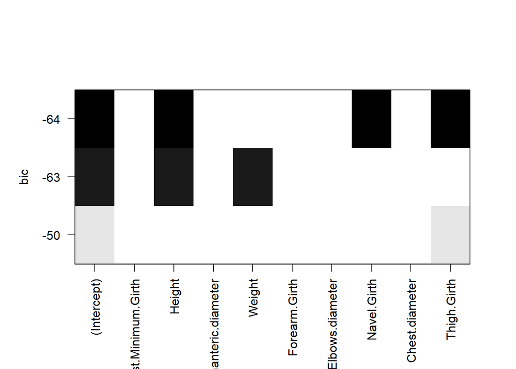

```r
library(dplyr)

# Asegurar que solo estén las variables seleccionadas y la variable dependiente
datos_entMR <- datos_ent[, c(predictores, "EN", "Thigh.Girth")]

# Evaluar todas las combinaciones de predictores
modelo_seleccion <- regsubsets(EN ~ ., data = datos_entMR, nbest = 1, nvmax = 3, method = "exhaustive")

# Graficar los resultados
plot(modelo_seleccion)
```

```r
# Extraer los mejores subconjuntos según BIC y R² ajustado
resumen_modelo <- summary(modelo_seleccion)

i_bic_min <- which.min(resumen_modelo$bic)
i_r2a_max <- which.max(resumen_modelo$adjr2)

mejor_comb_bic <- resumen_modelo$which[i_bic_min, ]
mejor_comb_r2a <- resumen_modelo$which[i_r2a_max, ]

# Eliminar la columna "(Intercept)" antes de extraer nombres
mejor_comb_bic <- mejor_comb_bic[names(mejor_comb_bic) != "(Intercept)"]
mejor_comb_r2a <- mejor_comb_r2a[names(mejor_comb_r2a) != "(Intercept)"]

# Extraer nombres de variables seleccionadas
vars_bic <- names(mejor_comb_bic[mejor_comb_bic == TRUE])
vars_r2a <- names(mejor_comb_r2a[mejor_comb_r2a == TRUE])

# Eliminar posibles variables indicadoras si es necesario
vars_bic <- unique(gsub("^(.*)\\d+$", "\\1", vars_bic))
vars_r2a <- unique(gsub("^(.*)\\d+$", "\\1", vars_r2a))

# Crear las fórmulas de los modelos
formula_bic <- as.formula(paste("EN ~", paste(vars_bic, collapse = " + ")))
formula_r2a <- as.formula(paste("EN ~", paste(vars_r2a, collapse = " + ")))

# Ajustar los modelos
modelo_bic <- glm(formula_bic, data = datos_entMR, family = binomial(link = "logit"))
modelo_r2a <- glm(formula_r2a, data = datos_entMR, family = binomial(link = "logit"))

# Mostrar los resultados
cat("Modelo que minimiza el BIC:\n")
```

```
## Modelo que minimiza el BIC:
```

```r
cat("----------------------------\n")
print(modelo_bic)
```

```
##
## Call:  glm(formula = formula_bic, family = binomial(link = "logit"),
##     data = datos_entMR)
##
## Coefficients:
## (Intercept)       Height  Navel.Girth  Thigh.Girth
##    -19.4409      -0.1924       0.1788       0.6116
##
## Degrees of Freedom: 99 Total (i.e. Null);  96 Residual
## Null Deviance:       138.6
## Residual Deviance: 50.55     AIC: 58.55
```

```r
cat("\nModelo que maximiza el R² ajustado:\n")
```

```
##
## Modelo que maximiza el R² ajustado:
```

```r
cat("------------------------------------\n")
print(modelo_r2a)
```

```
##
## Call:  glm(formula = formula_r2a, family = binomial(link = "logit"),
##     data = datos_entMR)
##
## Coefficients:
## (Intercept)       Height  Navel.Girth  Thigh.Girth
##    -19.4409      -0.1924       0.1788       0.6116
##
## Degrees of Freedom: 99 Total (i.e. Null);  96 Residual
## Null Deviance:       138.6
## Residual Deviance: 50.55     AIC: 58.55
```

Ahora, vamos a comparar los modelos obtenidos con el modelo que solo incluye la variable Thigh.Girth. Para esto, usaremos la prueba de razón de verosimilitud (LRT) para evaluar si los modelos son significativamente mejores que el modelo nulo.

```r
modelo <- glm(EN ~ Height + Navel.Girth + Thigh.Girth, family = binomial(link = "logit"), data = datos_ent)
print(summary(modelo))
```

```
##
## Call:
## glm(formula = EN ~ Height + Navel.Girth + Thigh.Girth, family = binomial(link = "logit"),
##     data = datos_ent)
##
## Coefficients:
##              Estimate Std. Error z value Pr(>|z|)
## (Intercept) -19.44094   10.16954  -1.912 0.055917 .
## Height       -0.19238    0.06974  -2.758 0.005809 **
## Navel.Girth   0.17884    0.05703   3.136 0.001714 **
## Thigh.Girth   0.61158    0.15999   3.823 0.000132 ***
## ---
## Signif. codes:  0 '***' 0.001 '**' 0.01 '*' 0.05 '.' 0.1 ' ' 1
##
## (Dispersion parameter for binomial family taken to be 1)
##
##     Null deviance: 138.629  on 99  degrees of freedom
## Residual deviance:  50.552  on 96  degrees of freedom
## AIC: 58.552
##
## Number of Fisher Scoring iterations: 7
```

```r
rlogitm_lrt <- anova(modelo_nulo, modelo, test = "LRT")
cat("Bondad de ajuste del modelo multivariado:\n")
```

```
## Bondad de ajuste del modelo multivariado:
```

```r
print(rlogitm_lrt)
```

```
## Analysis of Deviance Table
##
## Model 1: EN ~ Thigh.Girth
## Model 2: EN ~ Height + Navel.Girth + Thigh.Girth
##   Resid. Df Resid. Dev Df Deviance  Pr(>Chi)
## 1        98     77.908
## 2        96     50.552  2   27.356 1.148e-06 ***
## ---
## Signif. codes:  0 '***' 0.001 '**' 0.01 '*' 0.05 '.' 0.1 ' ' 1
```

Una vez que tenemos el modelo, se evaluará su confiabilidad, para esto se deben cumplir 6 condiciones:

1. Debe existir una relación lineal entre los predictores y la respuesta transformada: Para revisar esta condición se utilizaremos los gráficos de residuos:

```r
library(car)
```

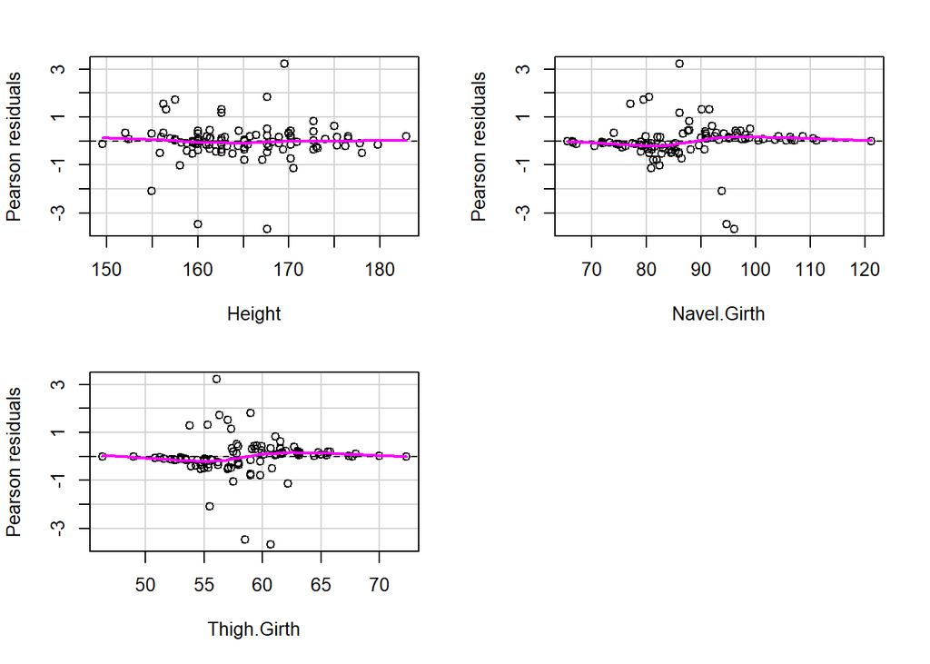

```
##             Test stat Pr(>|Test stat|)
## Height         0.0755           0.7835
## Navel.Girth    0.0128           0.9100
## Thigh.Girth    0.0599           0.8066
```

```r
library(dplyr)
#Relación linea predictores y respuesta transformada
residualPlots(modelo,fitted=FALSE)
```

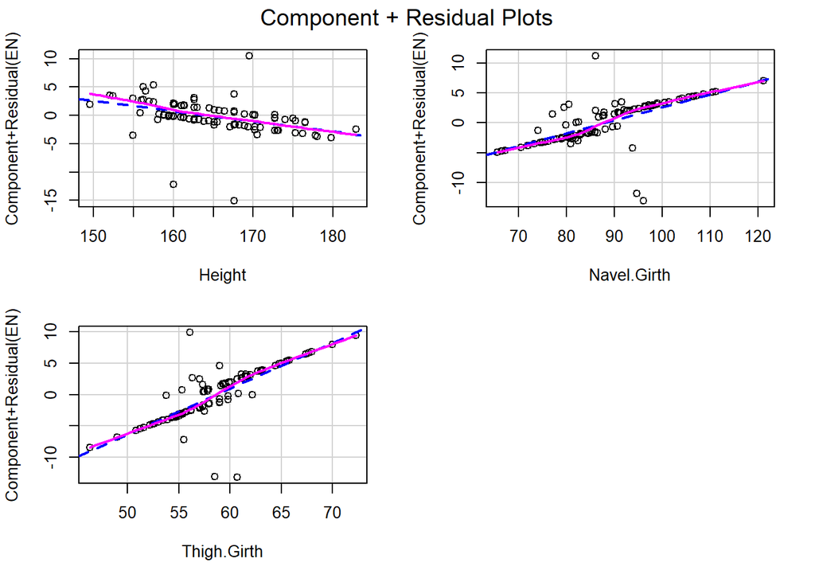

```r
crPlots(modelo)
```

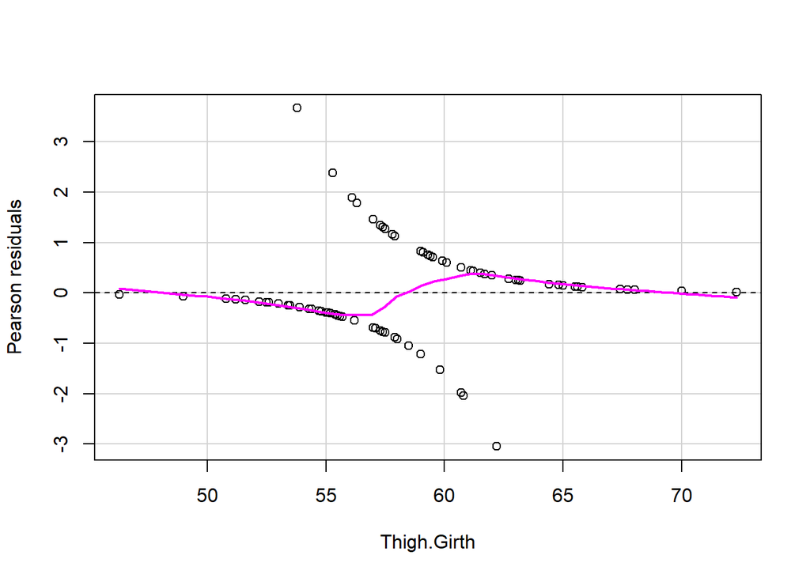

```
##             Test stat Pr(>|Test stat|)
## Thigh.Girth    0.0517           0.8202
```

```r
residualPlots(modelo_nulo,fitted=FALSE)
```

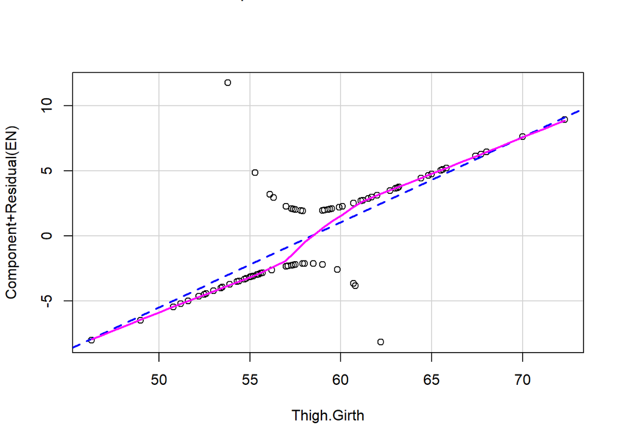

```r
crPlots(modelo_nulo)
```

Podemos ver que en los 3 gráficos del modelo logístico múltiple pareciera ser que el supuesto de linealidad se cumple.

Por otro lado el gráfico del modelo logístico simple pareciera seguir algún tipo de patrón exponencial, lo cual tiene sentido por la naturaleza de los datos.

2. Los residuos deben ser independientes entre sí: Para esta condición utilizaremos la prueba de Durbin-Watson:

```r
#Los residuos deben ser independientes entre si
db <- durbinWatsonTest(modelo)
db_nulo <- durbinWatsonTest(modelo_nulo)
cat("\nPrueba de Independencia RLogM: \n")
```

```
##
## Prueba de Independencia RLogM:
```

```r
print(db)
```

```
##  lag Autocorrelation D-W Statistic p-value
##    1    -0.003934116       1.91077   0.674
##  Alternative hypothesis: rho != 0
```

```r
cat ("\nPrueba de Independencia RLogs: \n")
```

```
##
## Prueba de Independencia RLogs:
```

```r
print(db_nulo)
```

```
##  lag Autocorrelation D-W Statistic p-value
##    1      0.06739747      1.825152   0.392
##  Alternative hypothesis: rho != 0
```

Con esto descartamos en ambos modelos que exista evidencia para sospechar que no se esté cumpliendo la condicién de independencia de los residuos, es importante destacar que para esta prueba fue necesario hacer una mezcla de los datos, de modo que estos no se encuentren ordenados.

3. Multicolinealidad entre los predictores:

Para evaluar esta condición utilizaremos los factores de inflación de la varianza (VIF):

```r
#Multicolinealidad de los predictores
vif(modelo)
```

```
##      Height Navel.Girth Thigh.Girth
##    1.484275    1.068128    1.451490
```

Podemos ver como cada predictores obtiene un valor muy cercano a 1, lo que indica que no hay multicolinealidad fuerte entre los predictores. Es importante señalar que para esta condición no se prueba el modelo de regresión logística simple, ya que este solo tiene un predictor y por lo tanto no se puede evaluar la multicolinealidad.

4. Información incompleta:

Para evaluar esta condición consideramos que no hay información incompleta, ya que no se cuentan con datos suficientes, considerando que se tiene una variable categórica de 2 niveles.

5. Separación perfecta:

6. Las estimaciones de los coeficientes del modelo no están dominadas por casos influyentes:

Para evaluar esta condición utilizaremos el gráfico de influencia de Cook y la distancia de Cook:

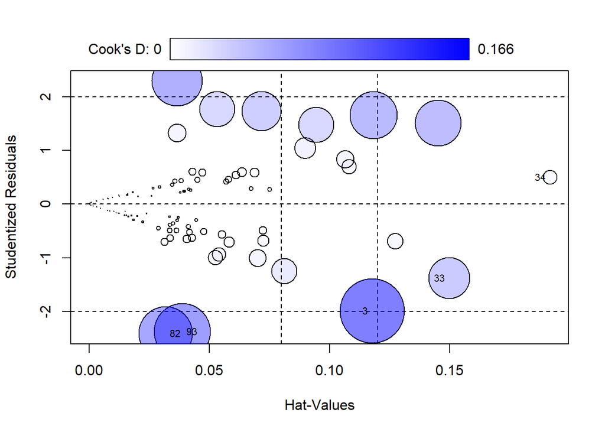

```r
#Las estimaciones de los coeficientes del modelo no estan dominadas por casos influyentes
casos_influyentes <- influencePlot(modelo, id = list(cex = 0.7))
```

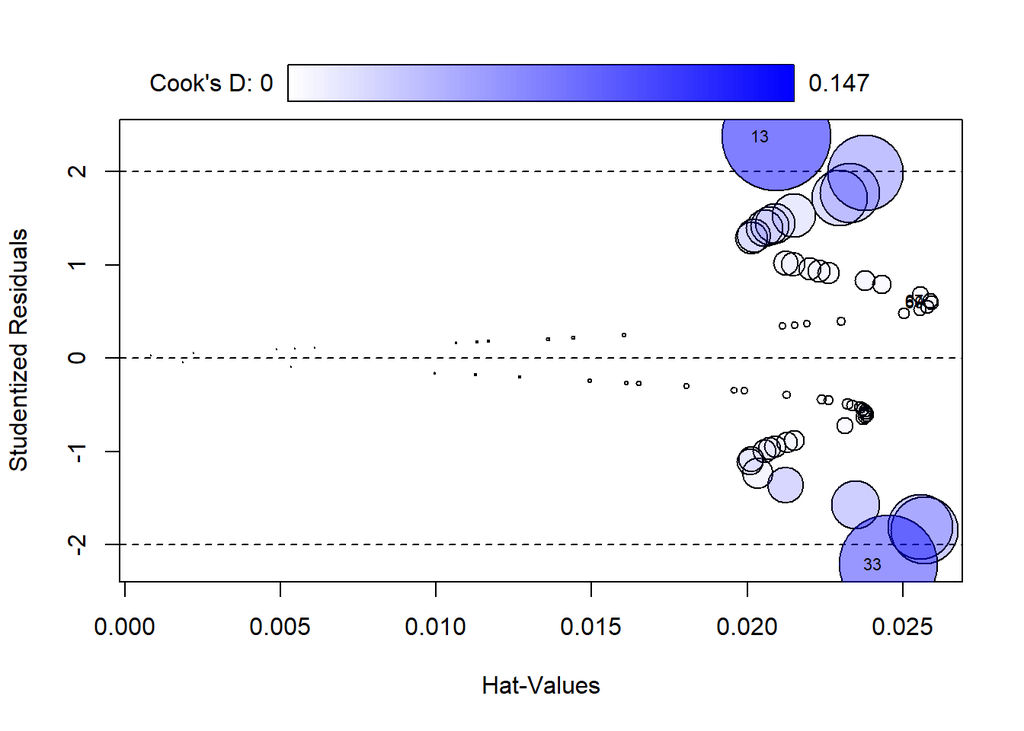

```r
casos_influyentes_nulo <- influencePlot(modelo_nulo, id = list(cex = 0.7))
```

```r
cat("\n Casos que podrían ser influyentes RlogM: \n")
```

```
##
##  Casos que podrían ser influyentes RlogM:
```

```r
print(casos_influyentes)
```

```
##       StudRes        Hat       CookD
## 3  -1.9876399 0.11786178 0.165858903
## 33 -1.3786242 0.14979445 0.067633875
## 34  0.4948182 0.19181424 0.008437288
## 82 -2.4088987 0.03179243 0.115019131
## 93 -2.3726080 0.03874013 0.126629414
```

```r
cat("\n Casos que podrían ser influyentes RlogS: \n")
```

```
##
##  Casos que podrían ser influyentes RlogS:
```

```r
print(casos_influyentes_nulo)
```

```
##       StudRes        Hat       CookD
## 13  2.3727909 0.02093462 0.146949338
## 33 -2.2121148 0.02454477 0.119664470
## 67  0.6121306 0.02589543 0.002767327
## 80  0.5962247 0.02590870 0.002614192
```

Con esto podemos ver que no hay casos influyentes, ya que ningún valor supera el valor crítico de 1.

Podemos concluir entonces que el modelo cumple con las condiciones necesarias para ser confiable y se puede utilizar para predecir el estado nutricional (EN) de las personas en el conjunto de datos.

Finalmente, se analizará la calidad predictiva de los modelos en términos de la sensibilidad y especificidad :

Para esto obtenemos el modelo

```r
train_logit <- function(formula, data, folds = 10, positive = "Sobrepeso", threshold = 0.5) {
  set.seed(4263)
  n <- nrow(data)
  indices <- sample(rep(1:folds, length.out = n))
  resultados_cv <- data.frame(
    Fold = integer(),
    Accuracy = numeric(),
    Sensitivity = numeric(),
    Specificity = numeric()
  )

  for (k in 1:folds) {
    test_idx <- which(indices == k)
    train_idx <- setdiff(1:n, test_idx)
    modelo_cv <- glm(formula, data = data[train_idx, ], family = binomial(link = "logit"))
    probas <- predict(modelo_cv, newdata = data[test_idx, ], type = "response")
    clases <- unique(data[[as.character(formula[[2]])]])
    clase_neg <- setdiff(clases, positive)
    pred <- ifelse(probas > threshold, positive, clase_neg)
    real <- data[test_idx, as.character(formula[[2]])]

    TP <- sum(pred == positive & real == positive)
    TN <- sum(pred == clase_neg & real == clase_neg)
    FP <- sum(pred == positive & real == clase_neg)
    FN <- sum(pred == clase_neg & real == positive)

    sensibilidad <- ifelse((TP + FN) == 0, NA, TP / (TP + FN))
    especificidad <- ifelse((TN + FP) == 0, NA, TN / (TN + FP))
    exactitud <- mean(pred == real)

    resultados_cv <- rbind(resultados_cv, data.frame(
      Fold = k,
      Accuracy = exactitud,
      Sensitivity = sensibilidad,
      Specificity = especificidad
    ))
  }

  modelo <- glm(formula, data = data, family = binomial(link = "logit"))
  resumen <- summary(modelo)
  probas_full <- predict(modelo, newdata = data, type = "response")
  clases <- unique(data[[as.character(formula[[2]])]])
  clase_neg <- setdiff(clases, positive)
  pred_full <- ifelse(probas_full > threshold, positive, clase_neg)
  real_full <- data[[as.character(formula[[2]])]]

  TP <- sum(pred_full == positive & real_full == positive)
  TN <- sum(pred_full == clase_neg & real_full == clase_neg)
  FP <- sum(pred_full == positive & real_full == clase_neg)
  FN <- sum(pred_full == clase_neg & real_full == positive)
  sensibilidad <- ifelse((TP + FN) == 0, NA, TP / (TP + FN))
  especificidad <- ifelse((TN + FP) == 0, NA, TN / (TN + FP))
  exactitud <- mean(pred_full == real_full)

  list(
    finalModel = modelo,
    resumen_modelo = resumen,
    resultados_cv = resultados_cv,
    sensibilidad = sensibilidad,
    especificidad = especificidad,
    exactitud = exactitud
  )
}

modelo_ent <- train_logit(
  EN ~ Height + Navel.Girth + Thigh.Girth,
  data = datos_ent,
  folds = 10,
  positive = "Sobrepeso"
)

print(modelo_ent$resumen_modelo)
```

```
##
## Call:
## glm(formula = formula, family = binomial(link = "logit"), data = data)
##
## Coefficients:
##              Estimate Std. Error z value Pr(>|z|)
## (Intercept) -19.44094   10.16954  -1.912 0.055917 .
## Height       -0.19238    0.06974  -2.758 0.005809 **
## Navel.Girth   0.17884    0.05703   3.136 0.001714 **
## Thigh.Girth   0.61158    0.15999   3.823 0.000132 ***
## ---
## Signif. codes:  0 '***' 0.001 '**' 0.01 '*' 0.05 '.' 0.1 ' ' 1
##
## (Dispersion parameter for binomial family taken to be 1)
##
##     Null deviance: 138.629  on 99  degrees of freedom
## Residual deviance:  50.552  on 96  degrees of freedom
## AIC: 58.552
##
## Number of Fisher Scoring iterations: 7
```

```r
print(modelo_ent$resultados_cv)
```

```
##    Fold Accuracy Sensitivity Specificity
## 1     1      1.0   1.0000000   1.0000000
## 2     2      0.7   0.7142857   0.6666667
## 3     3      0.8   0.6666667   0.8571429
## 4     4      1.0   1.0000000   1.0000000
## 5     5      0.9   1.0000000   0.8000000
## 6     6      1.0   1.0000000   1.0000000
## 7     7      0.8   0.8333333   0.7500000
## 8     8      0.8   0.7500000   0.8333333
## 9     9      0.9   0.8333333   1.0000000
## 10   10      0.9   0.8333333   1.0000000
```

Podemos ver que todos los predictores seleccionados son estadísticamente significativos, ya que todos tienen un valor-p menor a 0.01. Antes de concluir con lo dedmás, verémos también la calidad predictiva del modelo en el conjunto de prueba y entrenamiento, para esto se calculará la matriz de confusión, la exactitud, sensibilidad y especificidad. Además, se graficará la curva ROC para evaluar el rendimiento del modelo.

```r
# calculo de matriz de confusion
calcular_metricas <- function(pred, real, positive = "Sobrepeso") {
  pred <- factor(pred, levels = c("No_sobrepeso", "Sobrepeso"))
  real <- factor(real, levels = c("No_sobrepeso", "Sobrepeso"))

  TP <- sum(pred == positive & real == positive)
  TN <- sum(pred != positive & real != positive)
  FP <- sum(pred == positive & real != positive)
  FN <- sum(pred != positive & real == positive)

  exactitud <- mean(pred == real)
  sensibilidad <- ifelse((TP + FN) == 0, NA, TP / (TP + FN))
  especificidad <- ifelse((TN + FP) == 0, NA, TN / (TN + FP))

  matriz <- matrix(c(TN, FP, FN, TP), nrow = 2, byrow = TRUE,
                   dimnames = list("Real" = c("No_sobrepeso", "Sobrepeso"),
                                   "Predicho" = c("No_sobrepeso", "Sobrepeso")))

  list(
    tabla = matriz,
    exactitud = exactitud,
    sensibilidad = sensibilidad,
    especificidad = especificidad
  )
}
```

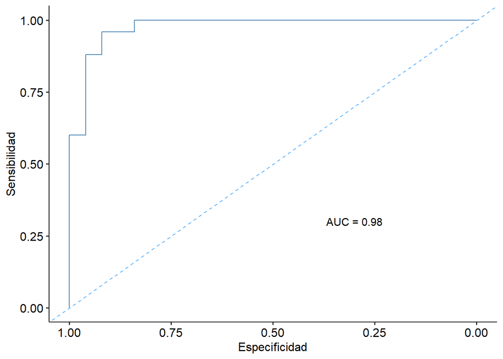

```r
library(pROC)


modelo_final <- modelo_ent$finalModel
probs_pru <- predict(modelo_final, newdata = datos_pru, type = "response")

#Para graficar:

ROC_pru <- roc(datos_pru[["EN"]], probs_pru,
               levels = c("No_sobrepeso", "Sobrepeso"), direction = "<")
g_ROC_pru <- ggroc(ROC_pru, color = "steelblue")
g_ROC_pru <- g_ROC_pru + geom_abline(intercept = 1, slope = 1, colour = "steelblue1", linetype = "dashed")
g_ROC_pru <- g_ROC_pru + xlab("Especificidad") + ylab("Sensibilidad")
texto_pru <- sprintf("AUC = %.2f", ROC_pru[["auc"]])
g_ROC_pru <- g_ROC_pru + annotate("text", x = 0.3, y = 0.3, label = texto_pru)
g_ROC_pru <- g_ROC_pru + theme_pubr()
print(g_ROC_pru)
```

```r
#Para obtener las predicciones en el mismo umbral:
pred <- sapply(probs_pru, function(p) ifelse(p >= 0.5, "Sobrepeso", "No_sobrepeso"))
pred <- factor(pred, levels = c("No_sobrepeso", "Sobrepeso"))

matriz <- calcular_metricas(pred, datos_pru$EN, "Sobrepeso")
cat("\n \n Evaluación del modelo (conjunto de prueba): \n")
```

```
##
##
##  Evaluación del modelo (conjunto de prueba):
```

```r
cat("---------------\n")
print(matriz$tabla)
```

```
##               Predicho
## Real           No_sobrepeso Sobrepeso
##   No_sobrepeso           23         2
##   Sobrepeso               3        22
```

```r
cat(sprintf (" Exactitud: %.3f \n", matriz$exactitud))
```

```
##  Exactitud: 0.900
```

```r
cat(sprintf (" Sensibilidad: %.3f \n", matriz$sensibilidad))
```

```
##  Sensibilidad: 0.880
```

```r
cat(sprintf (" Especificidad: %.3f \n", matriz$especificidad))
```

```
##  Especificidad: 0.920
```

```r
#Para los datos de entrenamiento:

probs_ent <- predict(modelo_final, newdata = datos_ent, type = "response")
pred_ent <- ifelse(probs_ent >= 0.5, "Sobrepeso", "No_sobrepeso")
pred_ent <- factor(pred_ent, levels = c("No_sobrepeso", "Sobrepeso"))
real_ent <- factor(datos_ent$EN, levels = c("No_sobrepeso", "Sobrepeso"))

matriz_ent <- calcular_metricas(pred_ent, real_ent, "Sobrepeso")

cat("\n \n Evaluación del modelo (conjunto de prueba): \n")
```

```
##
##
##  Evaluación del modelo (conjunto de prueba):
```

```r
cat("---------------\n")
print(matriz_ent$tabla)
```

```
##               Predicho
## Real           No_sobrepeso Sobrepeso
##   No_sobrepeso           45         5
##   Sobrepeso               7        43
```

```r
cat(sprintf (" Exactitud: %.3f \n", matriz_ent$exactitud))
```

```
##  Exactitud: 0.880
```

```r
cat(sprintf (" Sensibilidad: %.3f \n", matriz_ent$sensibilidad))
```

```
##  Sensibilidad: 0.860
```

```r
cat(sprintf (" Especificidad: %.3f \n", matriz_ent$especificidad))
```

```
##  Especificidad: 0.900
```

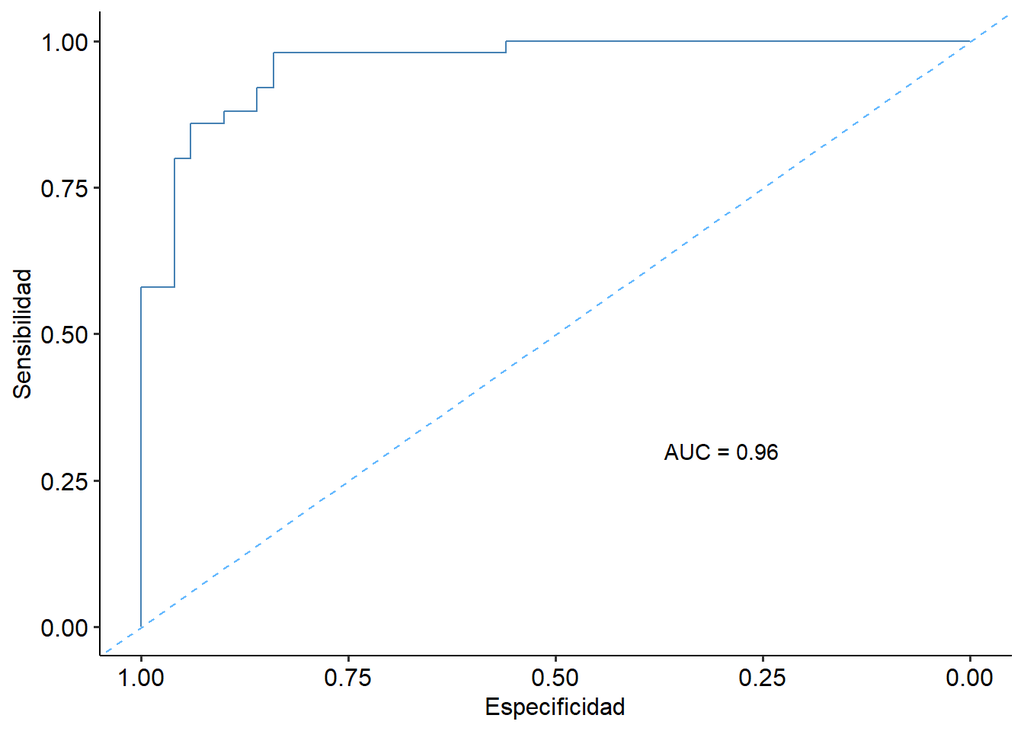

```r
#Para graficar:
ROC_pru <- roc(datos_ent[["EN"]], probs_ent,
               levels = c("No_sobrepeso", "Sobrepeso"), direction = "<")
g_ROC_ent <- ggroc(ROC_pru, color = "steelblue")
g_ROC_ent <- g_ROC_ent + geom_abline(intercept = 1, slope = 1, colour = "steelblue1", linetype = "dashed")
g_ROC_ent <- g_ROC_ent + xlab("Especificidad") + ylab("Sensibilidad")
texto_pru <- sprintf("AUC = %.2f", ROC_pru[["auc"]])
g_ROC_ent <- g_ROC_ent + annotate("text", x = 0.3, y = 0.3, label = texto_pru)
g_ROC_ent <- g_ROC_ent + theme_pubr()
print(g_ROC_ent)
```